# Data Science

Predicting Delivery Duration

Suhas Srinivasan

## Section 1

### Data Exploration and Cleaning

We begin by exploring the CSV files `historical_data` (training) and `predict_data` (testing) to gauge their quality. The datat is first checked for missing fields in the training and testing samples.

```r
input_hist_data = './data/historical_data.csv'
frame_hist_data = read.csv(input_hist_data, stringsAsFactors = F)
head(frame_hist_data)
```

|  | market_id | created_at | actual_delivery_time | store_id | subtotal | total_onshift_drivers | total_busy_drivers | total_outstanding_orders | estimated_store_to_consumer_driving_duration |
| --- | --- | --- | --- | --- | --- | --- | --- | --- | --- |
| 1 | 1 | 2015-02-06 22:24:17 | 2015-02-06 23:27:16 | 1845 | 3441 | 33 | 14 | 21 | 861 |
| 2 | 2 | 2015-02-10 21:49:25 | 2015-02-10 22:56:29 | 5477 | 1900 | 1 | 2 | 2 | 690 |
| 3 | 3 | 2015-01-22 20:39:28 | 2015-01-22 21:09:09 | 5477 | 1900 | 1 | 0 | 0 | 690 |
| 4 | 3 | 2015-02-03 21:21:45 | 2015-02-03 22:13:00 | 5477 | 6900 | 1 | 1 | 2 | 289 |
| 5 | 3 | 2015-02-15 02:40:36 | 2015-02-15 03:20:26 | 5477 | 3900 | 6 | 6 | 9 | 650 |
| 6 | 3 | 2015-01-28 20:30:38 | 2015-01-28 21:08:58 | 5477 | 5000 | 2 | 2 | 2 | 338 |

```r
input_pdct_data = './data/predict_data.csv'
frame_pdct_data = read.csv(input_pdct_data, stringsAsFactors = F)
head(frame_pdct_data)
```

|  | market_id | created_at | store_id | subtotal | total_onshift_drivers | total_busy_drivers | total_outstanding_orders | estimated_store_to_consumer_driving_duration | delivery_id |
| --- | --- | --- | --- | --- | --- | --- | --- | --- | --- |
| 1 | 3 | 2015-02-25 02:22:30 | 5477 | 7500 | 4 | 4 | 4 | 670 | 194096 |
| 2 | 3 | 2015-02-25 01:14:19 | 5477 | 7100 | 4 | 1 | 1 | 446 | 236895 |
| 3 | 4 | 2015-02-22 02:27:44 | 5477 | 4500 | 9 | 7 | 6 | 504 | 190868 |
| 4 | 3 | 2015-02-25 01:32:39 | 5477 | 1700 | 3 | 3 | 3 | 687 | 183076 |
| 5 | 1 | 2015-02-24 05:20:45 | 2841 | 3150 | 4 | 4 | 4 | 528 | 186200 |
| 6 | 1 | 2015-02-22 01:43:41 | 2841 | 6815 | 5 | 3 | 3 | 837 | 86219 |

```r
# Count number of missing fields in each column
cat('Missing fields in training data\n')
```

```
Missing fields in training data
```

```r
colSums(is.na(frame_hist_data))
```

```
                                   market_id                                   created_at
                                         987                                            0
                        actual_delivery_time                                     store_id
                                           7                                            0
                                    subtotal                        total_onshift_drivers
                                           0                                        16262
                          total_busy_drivers                     total_outstanding_orders
                                       16262                                        16262
estimated_store_to_consumer_driving_duration
                                         526
```

```r
cat('\nMissing fields in testing data\n')
```

```
Missing fields in testing data
```

```r
colSums(is.na(frame_pdct_data))
```

```
                                   market_id                                   created_at
                                         250                                            0
                                    store_id                                     subtotal
                                           0                                            0
                       total_onshift_drivers                           total_busy_drivers
                                        4633                                         4633
                    total_outstanding_orders estimated_store_to_consumer_driving_duration
                                        4633                                           11
                                 delivery_id
                                           0
```

```r
# Find total percent of rows with missing data
cat('\nPercent of rows missing data in training data\n')
```

```
Percent of rows missing data in training data
```

```r
cat(sum(!complete.cases(frame_hist_data)) * 100 / nrow(frame_hist_data))
```

```
8.949592
```

```r
cat('\nPercent of rows missing data in testing data\n')
```

```
Percent of rows missing data in testing data
```

```r
cat(sum(!complete.cases(frame_pdct_data)) * 100 / nrow(frame_pdct_data))
```

```
8.881303
```

Approximately 9% of samples/rows having missing fileds in each dataset. To cleanse the missing data, we must understand the information encoded by the variables and the necessary assumptions for modeling.  
Even though the corrupt samples account for only 1/10th of each dataset and imputation could introduce bias, the naive method of dropping rows with missing fields is not appropriate here as we have to generate a prediction for each `delivery_id` in the testing data.

We want to verify if **time-series modeling** and associated data cleansing steps are necessary for this dataset. As there are hundreds/thousands of unique stores in each market, it is hard to visualize all of them, hence observing the distribution of timestamps in the ordered dataframe can provide some information about the sampling rate.

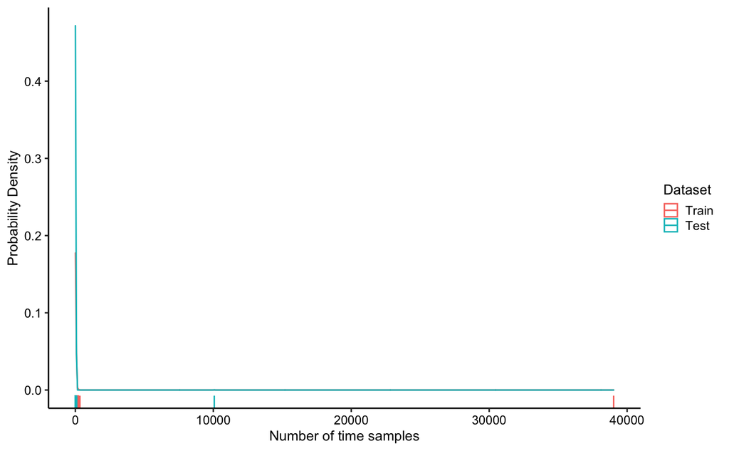

```r
# Convert character time to POSIXct for time representation and computation
# Maintain the UTC/GMT time zone originally present in the data
frame_hist_data$created_at = as.POSIXct(frame_hist_data$created_at, tz = "GMT")
frame_hist_data$actual_delivery_time = as.POSIXct(frame_hist_data$actual_delivery_time, tz = "GMT")
frame_pdct_data$created_at = as.POSIXct(frame_pdct_data$created_at, tz = "GMT")

# Rearrange columns for comparison
frame_hist_data = frame_hist_data[ , c('market_id', 'store_id',
                                       'created_at', 'subtotal',
                                       'total_onshift_drivers', 'total_busy_drivers',
                                       'total_outstanding_orders',
                                       'estimated_store_to_consumer_driving_duration', 'actual_delivery_time')]
frame_pdct_data = frame_pdct_data[ , c('market_id', 'store_id',
                                       'created_at', 'subtotal',
                                       'total_onshift_drivers', 'total_busy_drivers',
                                       'total_outstanding_orders',
                                       'estimated_store_to_consumer_driving_duration', 'delivery_id')]

# Order the dataframes by geo location and order creation time
frame_hist_data = frame_hist_data[order(frame_hist_data$market_id, frame_hist_data$store_id,
                                        frame_hist_data$created_at), ]
rownames(frame_hist_data) = NULL

frame_pdct_data = frame_pdct_data[order(frame_pdct_data$market_id, frame_pdct_data$store_id,
                                        frame_pdct_data$created_at), ]
rownames(frame_pdct_data) = NULL

# Count the number of time samples for all stores in the first market
store_id1 = unique(frame_hist_data[frame_hist_data$market_id == 1, 'store_id'])
times1 = c()
for (store_id1_ in store_id1) {
  times1 = c(times1, length(frame_hist_data[frame_hist_data$market_id == 1 &
                                            frame_hist_data$store_id == store_id1_, 'created_at']))
}

store_id1 = unique(frame_pdct_data[frame_pdct_data$market_id == 1, 'store_id'])
times2 = c()
for (store_id1_ in store_id1) {
  times2 = c(times2, length(frame_pdct_data[frame_pdct_data$market_id == 1 &
                                              frame_pdct_data$store_id == store_id1_, 'created_at']))
}

# Plot the distribution of time samples
library(ggplot2)

frame_plot = data.frame(Times = c(times1, times2), Dataset = c(rep('Train', length(times1)),
                                                               rep('Test', length(times2))))
frame_plot$Dataset = factor(frame_plot$Dataset, levels = unique(frame_plot$Dataset))

ggplot(frame_plot, aes(x = Times, group = Dataset, color = Dataset)) +
  geom_density() +
  geom_rug() +
  scale_x_continuous() +
  labs(x = 'Number of time samples', y = 'Probability Density') +
  theme(panel.background = element_rect(fill = 'white'),
        legend.key.size = unit(0.15, 'in'),
        legend.key = element_blank(),
        legend.text = element_text(size = 9),
        legend.title = element_text(size = 10),
        legend.position = 'right', legend.justification = c(0, 0.5), legend.direction = 'vertical',
        axis.line = element_line(), axis.title = element_text(size = 10, color = 'black'),
        axis.text.x = element_text(size = 9, color = 'black'),
        axis.text.y = element_text(size = 9, color = 'black'))
```

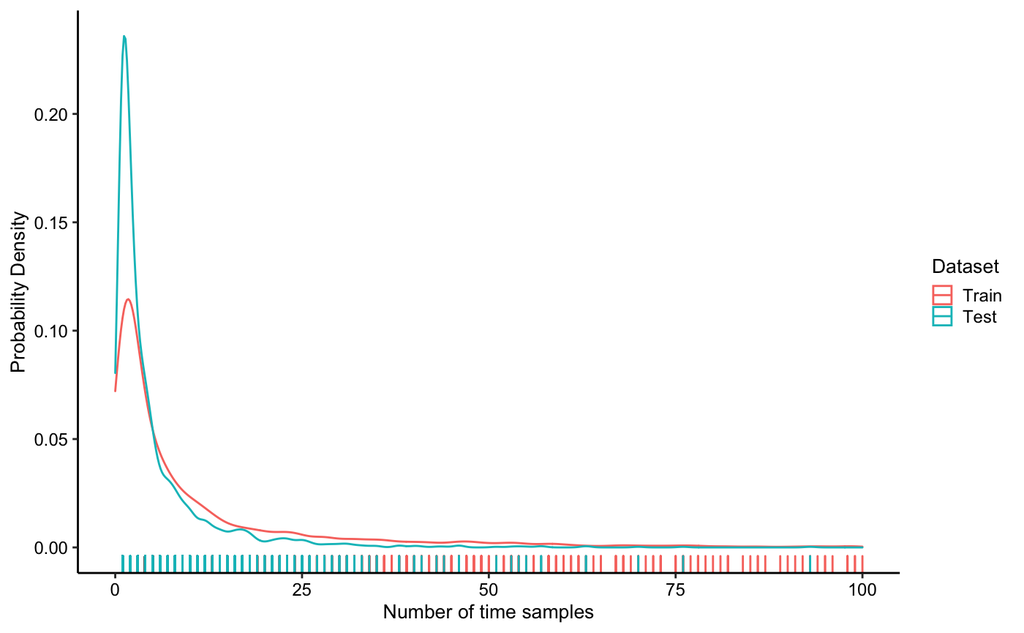

```r
# Zoom in x-axis range [0, 100]
ggplot(frame_plot, aes(x = Times, group = Dataset, color = Dataset)) +
  geom_density() +
  geom_rug() +
  scale_x_continuous(limits = c(0, 100)) +
  labs(x = 'Number of time samples', y = 'Probability Density') +
  theme(panel.background = element_rect(fill = 'white'),
        legend.key.size = unit(0.15, 'in'),
        legend.key = element_blank(),
        legend.text = element_text(size = 9),
        legend.title = element_text(size = 10),
        legend.position = 'right', legend.justification = c(0, 0.5), legend.direction = 'vertical',
        axis.line = element_line(), axis.title = element_text(size = 10, color = 'black'),
        axis.text.x = element_text(size = 9, color = 'black'),
        axis.text.y = element_text(size = 9, color = 'black'))
```

The plots show long tail distributions likely due to very popular stores that generate hundreds/thousands of orders. Browsing the dataframes and the above plots show that the data does not have the following characteristics:  
1. A consistent begin and end time period for each store.  
2. A consistent sampling frequency that can be used for time-series modeling.

The first variable to be handled for missing data is `market_id`, because in combination with `store_id` it can act as a unique global identifier for each store.

```r
# Extract unique store_id to find the difference with all other markets as a quick check
storesNA = unique(frame_hist_data[is.na(frame_hist_data$market_id), 'store_id'])
storesNNA = unique(frame_hist_data[!is.na(frame_hist_data$market_id), 'store_id'])
cat('Training data: No. of unique stores that do not belong to Markets 1-6\n')
```

```
Training data: No. of unique stores that do not belong to Markets 1-6
```

```r
cat(length(setdiff(storesNA, storesNNA)))
```

```
3
```

```r
storesNA = unique(frame_pdct_data[is.na(frame_pdct_data$market_id), 'store_id'])
storesNNA = unique(frame_pdct_data[!is.na(frame_pdct_data$market_id), 'store_id'])
cat('\nTesting data: No. of unique stores that do not belong to Markets 1-6\n')
```

```
Testing data: No. of unique stores that do not belong to Markets 1-6
```

```r
cat(length(setdiff(storesNA, storesNNA)))
```

```
6
```

```r
# Set new market_id and verify
frame_hist_data$market_id[is.na(frame_hist_data$market_id)] = 7
frame_pdct_data$market_id[is.na(frame_pdct_data$market_id)] = 7

cat('\n\nUpdated Market ID in training and testing data respectively')
```

```
Updated Market ID in training and testing data respectively
```

```r
table(frame_hist_data$market_id, useNA = 'always')
```

```
    1     2     3     4     5     6     7  <NA>
38037 55058 23297 47599 18000 14450   987     0
```

```r
table(frame_pdct_data$market_id, useNA = 'always')
```

```
    1     2     3     4     5     6     7  <NA>
 9819 15536  6233 13186  5564  4190   250     0
```

We find that there are a few unique stores in both datasets that do not belong to any existing markets. The missing `market_id` could be from existing cities or a new city, and there is no clear way of reconciling the missing `market_id`, thus we created a new 7th market for these stores (which can be updated correctly in the future if there is new information).

We need additional information about the delivery duration to identify any market specific patterns (we can check this only in the training data).  
As there is geographical information in the form of `store_id` and `market_id`, and studies show the impact of location on delivery services, we explore the quality of these variables first ( [Abousaeidi et al. 2015](https://www.sciencedirect.com/science/article/pii/S1319562X15001370), [Hubner et al. 2016](https://www.emerald.com/insight/content/doi/10.1108/IJRDM-11-2014-0154/full/html)).

We will clean the driver and order information variables: `total_onshift_drivers`, `total_busy_drivers` and `total_outstanding_orders`.  
We will impute the median value for each market. The median value avoids being skewed due to outliers and market specific imputation can further reduce data cleaning bias.

```r
# We know that the number of missing fields in each of the three variables are the same i.e. 16,262
# Check if a set of missing driver fields belong to the same row in training data
index1 = which(is.na(frame_hist_data[, 'total_onshift_drivers']))
index2 = which(is.na(frame_hist_data[, 'total_busy_drivers']))
index3 = which(is.na(frame_hist_data[, 'total_outstanding_orders']))
cat('No. of matching indices in training data\n')
```

```
No. of matching indices in training data
```

```r
cat(length(Reduce(intersect, list(index1, index2, index3))))
```

```
16262
```

```r
# We know that the number of missing fields in each of the three variables are the same i.e. 4,633
# Check if a set of missing driver fields belong to the same row in testing data
index1 = which(is.na(frame_pdct_data[, 'total_onshift_drivers']))
index2 = which(is.na(frame_pdct_data[, 'total_busy_drivers']))
index3 = which(is.na(frame_pdct_data[, 'total_outstanding_orders']))
cat('\nNo. of matching indices in testing data\n')
```

```
No. of matching indices in testing data
```

```r
cat(length(Reduce(intersect, list(index1, index2, index3))))
```

```
4633
```

```r
# Impute driver info in training data
markets = unique(frame_hist_data[is.na(frame_hist_data$total_onshift_drivers), 'market_id'])
for(market_id_ in markets) {
  frame_hist_data$total_onshift_drivers[is.na(frame_hist_data$total_onshift_drivers)] =
    median(frame_hist_data[frame_hist_data$market_id == market_id_, 'total_onshift_drivers'], na.rm = T)
  frame_hist_data$total_busy_drivers[is.na(frame_hist_data$total_busy_drivers)] =
    median(frame_hist_data[frame_hist_data$market_id == market_id_, 'total_busy_drivers'], na.rm = T)
  frame_hist_data$total_outstanding_orders[is.na(frame_hist_data$total_outstanding_orders)] =
    median(frame_hist_data[frame_hist_data$market_id == market_id_, 'total_outstanding_orders'], na.rm = T)
}

# Impute driver info in testing data
markets = unique(frame_pdct_data[is.na(frame_pdct_data$total_onshift_drivers), 'market_id'])
for(market_id_ in markets) {
  frame_pdct_data$total_onshift_drivers[is.na(frame_pdct_data$total_onshift_drivers)] =
    median(frame_pdct_data[frame_pdct_data$market_id == market_id_, 'total_onshift_drivers'], na.rm = T)
  frame_pdct_data$total_busy_drivers[is.na(frame_pdct_data$total_busy_drivers)] =
    median(frame_pdct_data[frame_pdct_data$market_id == market_id_, 'total_busy_drivers'], na.rm = T)
  frame_pdct_data$total_outstanding_orders[is.na(frame_pdct_data$total_outstanding_orders)] =
    median(frame_pdct_data[frame_pdct_data$market_id == market_id_, 'total_outstanding_orders'], na.rm = T)
}
cat('\nImputation of driver info complete')
```

```
Imputation of driver info complete
```

The final cleaning step is for the time and duration variables, by first removing seven samples that are missing `actual_delivery_time`, these could be because the order got cancelled or due to an error, it is a negligible sample size.  
We then impute `estimated_store_to_consumer_driving_duration` with the median value for each market.

```r
# Drop the seven samples that are missing actual_delivery_time
frame_hist_data = frame_hist_data[!is.na(frame_hist_data$actual_delivery_time), ]

# Impute estimated_store_to_consumer_driving_duration in training data
markets = unique(frame_hist_data[is.na(frame_hist_data$estimated_store_to_consumer_driving_duration), 'market_id'])
for(market_id_ in markets) {
  frame_hist_data$estimated_store_to_consumer_driving_duration[
    is.na(frame_hist_data$estimated_store_to_consumer_driving_duration)] =
    median(frame_hist_data[frame_hist_data$market_id == market_id_,
                           'estimated_store_to_consumer_driving_duration'], na.rm = T)
}

# Impute estimated_store_to_consumer_driving_duration in testing data
markets = unique(frame_pdct_data[is.na(frame_pdct_data$estimated_store_to_consumer_driving_duration), 'market_id'])
for(market_id_ in markets) {
  frame_pdct_data$estimated_store_to_consumer_driving_duration[
    is.na(frame_pdct_data$estimated_store_to_consumer_driving_duration)] =
    median(frame_pdct_data[frame_pdct_data$market_id == market_id_,
                           'estimated_store_to_consumer_driving_duration'], na.rm = T)
}

# Check imputed data
cat('After imputing training data\n')
```

```
After imputing training data
```

```r
colSums(is.na(frame_hist_data))
```

```
                                   market_id                                     store_id
                                           0                                            0
                                  created_at                                     subtotal
                                           0                                            0
                       total_onshift_drivers                           total_busy_drivers
                                           0                                            0
                    total_outstanding_orders estimated_store_to_consumer_driving_duration
                                           0                                            0
                        actual_delivery_time
                                           0
```

```r
cat('\nAfter imputing testing data\n')
```

```
After imputing testing data
```

```r
colSums(is.na(frame_pdct_data))
```

```
                                   market_id                                     store_id
                                           0                                            0
                                  created_at                                     subtotal
                                           0                                            0
                       total_onshift_drivers                           total_busy_drivers
                                           0                                            0
                    total_outstanding_orders estimated_store_to_consumer_driving_duration
                                           0                                            0
                                 delivery_id
                                           0
```

## Section 2

### Feature Engineering and Modeling

We will now define the modeling problem and required features and begin with the simple paradigm of linear regression assuming that the delivery time is a linear function of the available independent variables, defined as:  
$Y = f( X_i \beta)+ \epsilon_i$  
Where, $Y$ is the dependent variable i.e. delivery time, $X$ represents the independent variables, $\beta$ are the coefficients and $\epsilon$ the error terms.

We are required to predict the total delivery duration in seconds, which is defined as:  
$Total\ Delivery\ Duration\ (seconds) = Actual\ Delivery\ Time - Order\ Created \ Time$

Which in turn can be redefined as a prediction problem for the actual delivery time:  
$Actual\ Delivery\ Time = Order\ Created \ Time + Order\ Preparation\ Time + Store\ to\ Customer\ Time$

$Store\ to\ Customer\ Time = f(Available\ drivers + Outstanding\ Orders + Subtotal + Driving\ Time)$

Here we do not have information on order preparation time and store to customer time, however we have a proxy for the latter: `estimated_store_to_consumer_driving_duration`.  
**Note**: Ideally, order price should not be an influencing factor, however it is known that drivers try to maximize the order amount while minimizing driving distance for better profits.

We will create a new duration variable `total_delivery_duration`. This will allow us to observe the distribution of delivery duration and patterns for modeling.  
$Total\ Delivery\ Duration\ (seconds) = Actual\ Delivery\ Time - Order\ Created \ Time$

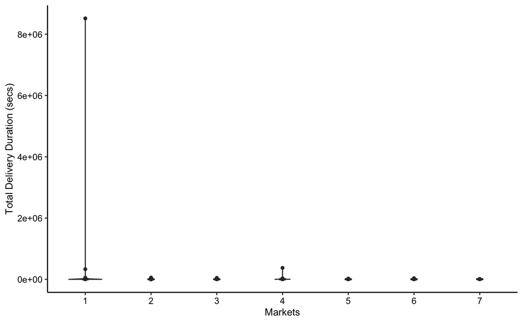

```r
# Calculate total delivery duration
frame_hist_data$total_delivery_duration = as.integer(difftime(frame_hist_data$actual_delivery_time,
                                                              frame_hist_data$created_at,  units = 'secs'))

# Visualize the distribution of total_delivery_duration in all markets
ggplot(data = frame_hist_data, aes(x = market_id, y = total_delivery_duration,
                                   group = market_id, fill = as.character(market_id))) +
  geom_violin(width = 0.5) +
  geom_boxplot(na.rm = T, width = 0.1, outlier.shape = 16, position = position_dodge(0.9), fill = 'white') +
  scale_x_continuous(breaks = c(1:7)) +
  labs(y = 'Total Delivery Duration (secs)', x = 'Markets') +
  theme(panel.background = element_rect(fill = 'white'),
        legend.key.size = unit(0.15, 'in'),
        legend.key = element_blank(),
        legend.text = element_text(size = 9),
        legend.title = element_text(size = 10),
        legend.position = 'none', legend.justification = c(0, 0.5), legend.direction = 'vertical',
        axis.line = element_line(), axis.title = element_text(size = 10, color = 'black'),
        axis.text.x = element_text(size = 9, color = 'black'),
        axis.text.y = element_text(size = 9, color = 'black'))
```

We find that there are many outliers in `total_delivery_duration` possibly due to anomalous entries in `actual_delivery_time` or `created_at`.  
These samples should be dropped as they can bias models since the target variable is `total_delivery_duration`.

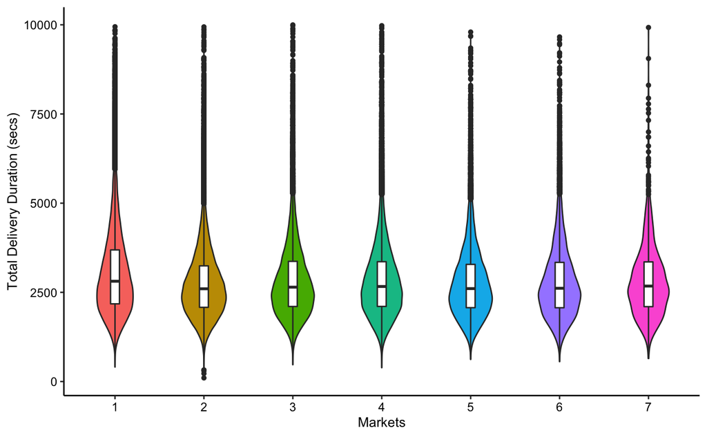

```r
# Drop the rows with the extreme outliers
frame_hist_data = frame_hist_data[frame_hist_data$total_delivery_duration <= 10000,  ]

ggplot(data = frame_hist_data, aes(x = market_id, y = total_delivery_duration,
                                   group = market_id, fill = as.character(market_id))) +
  geom_violin(width = 0.5) +
  geom_boxplot(na.rm = T, width = 0.1, outlier.shape = 16, position = position_dodge(0.9), fill = 'white') +
  scale_x_continuous(breaks = c(1:7)) +
  labs(y = 'Total Delivery Duration (secs)', x = 'Markets') +
  theme(panel.background = element_rect(fill = 'white'),
        legend.key.size = unit(0.15, 'in'),
        legend.key = element_blank(),
        legend.text = element_text(size = 9),
        legend.title = element_text(size = 10),
        legend.position = 'none', legend.justification = c(0, 0.5), legend.direction = 'vertical',
        axis.line = element_line(), axis.title = element_text(size = 10, color = 'black'),
        axis.text.x = element_text(size = 9, color = 'black'),
        axis.text.y = element_text(size = 9, color = 'black'))
```

With a zoomed in view of the y-axis, we observe the following: 1. There are still more outliers in each market that need to be removed.  
2. The medians of the distributions are fairly similar.

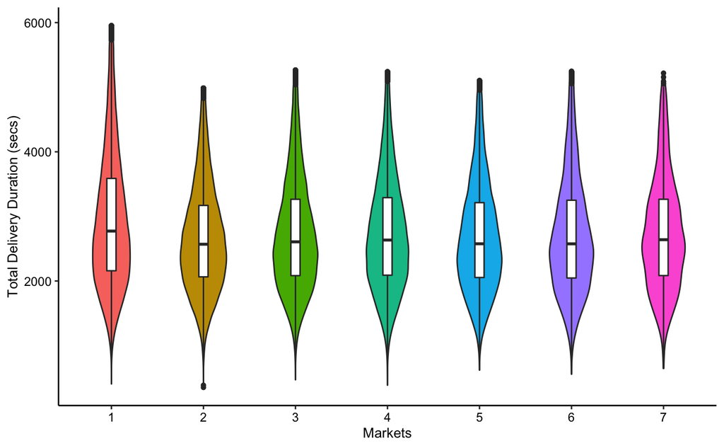

```r
markets = c(1:7)
cleaned_hist_data = frame_hist_data[1, ]
for (market_id_ in markets) {
  minmax = boxplot.stats(frame_hist_data[frame_hist_data$market_id == market_id_,
                              'total_delivery_duration'])$stats[c(1,5)]
  cleaned_hist_data = rbind(cleaned_hist_data, frame_hist_data[frame_hist_data$market_id == market_id_ &
                              frame_hist_data$total_delivery_duration >= minmax[1] &
                              frame_hist_data$total_delivery_duration <= minmax[2], ])
}
cleaned_hist_data = cleaned_hist_data[-1, ]

ggplot(data = cleaned_hist_data, aes(x = market_id, y = total_delivery_duration,
                                   group = market_id, fill = as.character(market_id))) +
  geom_violin(width = 0.5) +
  geom_boxplot(na.rm = T, width = 0.1, outlier.shape = 16, position = position_dodge(0.9), fill = 'white') +
  scale_x_continuous(breaks = c(1:7)) +
  labs(y = 'Total Delivery Duration (secs)', x = 'Markets') +
  theme(panel.background = element_rect(fill = 'white'),
        legend.key.size = unit(0.15, 'in'),
        legend.key = element_blank(),
        legend.text = element_text(size = 9),
        legend.title = element_text(size = 10),
        legend.position = 'none', legend.justification = c(0, 0.5), legend.direction = 'vertical',
        axis.line = element_line(), axis.title = element_text(size = 10, color = 'black'),
        axis.text.x = element_text(size = 9, color = 'black'),
        axis.text.y = element_text(size = 9, color = 'black'))
```

We will also create a new variable for a simpler representation of driver availability information.  
$Total\ Available\ drivers = Total\ Onshift\ drivers-Total\ Busy\ drivers$ This will also help us identify any issues with the original driver information.  
`total_busy_drivers` should be less than `total_onshift_drivers` since it is a subset of it.

```r
cleaned_hist_data$total_available_drivers = cleaned_hist_data$total_onshift_drivers - cleaned_hist_data$total_busy_drivers
frame_pdct_data$total_available_drivers = frame_pdct_data$total_onshift_drivers - frame_pdct_data$total_busy_drivers

# Check if there are negative values
cat('No. of negative values for driver availability in training and testing data\n')
```

```
No. of negative values for driver availability in training and testing data
```

```r
cat(sum(cleaned_hist_data$total_available_drivers < 0), '\n')
```

```
38887
```

```r
cat(sum(frame_pdct_data$total_available_drivers < 0))
```

```
619
```

```r
# Set these negative values to zero
cleaned_hist_data$total_available_drivers[cleaned_hist_data$total_available_drivers < 0] = 0
frame_pdct_data$total_available_drivers[frame_pdct_data$total_available_drivers < 0] = 0
cat('\nCreation of driver availability complete')
```

```
Creation of driver availability complete
```

We will now select the necessary features and create the linear regression model.  
We will avoid any transformations as the dependent variable has to be in seconds.  
We will use a random 80:20 split and 10-fold cross validation to estimate in two different ways the generalizability of the model.

```r
# Retain only informative features
cleaned_hist_data = cleaned_hist_data[ , c('created_at', 'subtotal',
                             'total_available_drivers', 'total_outstanding_orders',
                             'estimated_store_to_consumer_driving_duration', 'actual_delivery_time')]
cleaned_pdct_data = frame_pdct_data[ , c('created_at', 'subtotal',
                               'total_available_drivers', 'total_outstanding_orders',
                               'estimated_store_to_consumer_driving_duration')]

# Convert human readable time to only seconds for training and testing
cleaned_hist_data$created_at = as.integer(unclass(cleaned_hist_data$created_at))
cleaned_hist_data$actual_delivery_time = as.integer(unclass(cleaned_hist_data$actual_delivery_time))
cleaned_pdct_data$created_at = as.integer(unclass(cleaned_pdct_data$created_at))

# Use R-squared as a check
cat('Correlation in actual delivery time and order created time\n')
```

```
Correlation in actual delivery time and order created time
```

```r
cat(cor(cleaned_hist_data$actual_delivery_time, cleaned_hist_data$created_at) ^ 2)
```

```
0.9999983
```

```r
library(caret)
library(dplyr)
set.seed(111)

# Internal test for 20% held out historical data
sample_index = cleaned_hist_data$actual_delivery_time %>% createDataPartition(p = 0.8, list = FALSE)
train_data = cleaned_hist_data[sample_index, ]
test_data = cleaned_hist_data[-sample_index, ]
linear_model = lm(actual_delivery_time ~ ., data = train_data)
predictions = linear_model %>% predict(test_data)
data.frame(R2 = R2(predictions, test_data$actual_delivery_time),
            RMSE = RMSE(predictions, test_data$actual_delivery_time),
            MAE = MAE(predictions, test_data$actual_delivery_time))
```

| R2 | RMSE | MAE |
| --- | --- | --- |
| 0.9999986 | 818.0437 | 647.1812 |

```r
# 10-fold cross validation
train_control = trainControl(method = 'cv', number = 10)
start_time = Sys.time()
linear_model = train(actual_delivery_time ~ ., data = cleaned_hist_data, method = 'lm', trControl = train_control)
cat('Time taken to perform 10-fold CV:', Sys.time()-start_time, ' (secs)')
```

```
Time taken to perform 10-fold CV: 3.772514  (secs)
```

```r
# Summarize the model
linear_model  # Training errors
```

```
Linear Regression

191437 samples
     5 predictor

No pre-processing
Resampling: Cross-Validated (10 fold)
Summary of sample sizes: 172294, 172293, 172293, 172293, 172293, 172294, ...
Resampling results:

  RMSE     Rsquared   MAE
  821.456  0.9999986  649.8022

Tuning parameter 'intercept' was held constant at a value of TRUE
```

```r
linear_model$finalModel # Coefficients
```

```
Call:
lm(formula = .outcome ~ ., data = dat)

Coefficients:
                                 (Intercept)                                    created_at
                                  -7.100e+04                                     1.000e+00
                                    subtotal                       total_available_drivers
                                   1.038e-01                                    -1.662e+01
                    total_outstanding_orders  estimated_store_to_consumer_driving_duration
                                   3.652e+00                                     9.946e-01
```

The linear model in the case of 80:20 split and 10-fold CV is sufficiently accurate with a high $R^2$, and low $RMSE$ and $MAE$. This also shows that a global model could be sufficient.  
We will now build a model by training on the entire historical data and as a simple check, visualize the model through partial-regression plots. We will also retain the five features as the error is quite low.

```r
linear_model = lm(actual_delivery_time ~ ., data = cleaned_hist_data)
# Summarize the model
linear_model  # Coefficients
```

```
Call:
lm(formula = actual_delivery_time ~ ., data = cleaned_hist_data)

Coefficients:
                                 (Intercept)                                    created_at
                                  -7.100e+04                                     1.000e+00
                                    subtotal                       total_available_drivers
                                   1.038e-01                                    -1.662e+01
                    total_outstanding_orders  estimated_store_to_consumer_driving_duration
                                   3.652e+00                                     9.946e-01
```

[figure not shown]

```r
# Added-variable or partial-regression plots
library(car)
avPlots(linear_model, id = F)
```

As the final step, we will now use the trained model to predict `actual_delivery_time` in the prediction data and then generate the `total_delivery_duration`.

```r
# Make prediction
predictions = linear_model %>% predict(cleaned_pdct_data)

# Use R-squared as a check
cat('Correlation in predicted delivery time and order created time\n')
```

```
Correlation in predicted delivery time and order created time
```

```r
cat(cor(predictions, cleaned_pdct_data$created_at) ^ 2)
```

```
0.9999946
```

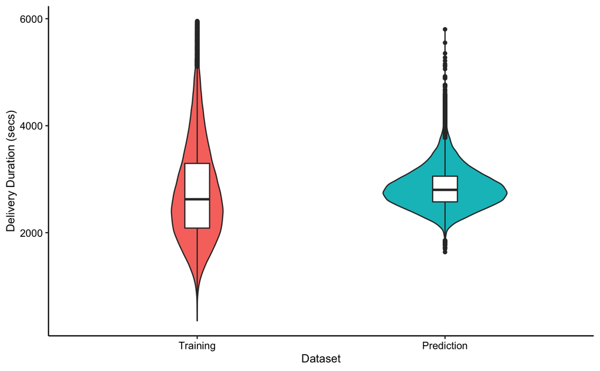

```r
# Round the predictions to the nearest second
frame_pdct_data$predicted_delivery_time = round(predictions, 0)

# Calculate the predicted_duration
frame_pdct_data$created_at = as.integer(unclass(frame_pdct_data$created_at))
frame_pdct_data$predicted_duration = frame_pdct_data$predicted_delivery_time - frame_pdct_data$created_at

frame_plot = data.frame(Duration = cleaned_hist_data$actual_delivery_time - cleaned_hist_data$created_at,
                  Dataset = 'Training')
frame_plot = rbind(frame_plot,
                   data.frame(Duration = frame_pdct_data$predicted_duration,
                              Dataset = rep('Prediction', nrow(frame_pdct_data))))
frame_plot$Dataset = factor(frame_plot$Dataset, levels = unique(frame_plot$Dataset))

ggplot(data = frame_plot, aes(x = Dataset, y = Duration, fill = Dataset)) +
  geom_violin(width = 0.5) +
  geom_boxplot(na.rm = T, width = 0.1, outlier.shape = 16, position = position_dodge(0.9), fill = 'white') +
  labs(y = 'Delivery Duration (secs)', x = 'Dataset') +
  theme(panel.background = element_rect(fill = 'white'),
        legend.key.size = unit(0.15, 'in'),
        legend.key = element_blank(),
        legend.text = element_text(size = 9),
        legend.title = element_text(size = 10),
        legend.position = 'none', legend.justification = c(0, 0.5), legend.direction = 'vertical',
        axis.line = element_line(), axis.title = element_text(size = 10, color = 'black'),
        axis.text.x = element_text(size = 9, color = 'black'),
        axis.text.y = element_text(size = 9, color = 'black'))
```

```r
# Save the two required columns to csv
write.csv(frame_pdct_data[ , c('delivery_id', 'predicted_duration')], './data/predicted_data.csv', row.names = F)
```

**Conclusion**: Compared to the historical data, the model’s prediction has lower variance and a slightly higher average delivery duration. As mentioned in the problem statement, this overestimating behavior is twice as better than underestimating the duration.